# Acheta Desiccation

- Show All Code
- Hide All Code
- View Source

Haemolymph volume

Author

Affiliation

Jacinta Kong

Department of Biology, Carleton Univeristy, Canada

Published

October 14, 2026

Aim: To measure haemolymph volume changes during desiccation.

# 1 Setup

```r
# Import only xlsx files
sheet_names <- excel_sheets("data/Desiccation 2025/haemolymph volume/HaemVolData.xlsx")

metadata <- read_excel("data/Desiccation 2025/haemolymph volume/HaemVolData.xlsx", sheet = "mass")

platemap <- map(sheet_names[-c(1:2)], read_excel,
      path = "data/Desiccation 2025/haemolymph volume/HaemVolData.xlsx", range = "A1:L8", col_names = paste(1:12))

spec <- map(c("20260211", "20260219", "20260225"), read_excel, path = "data/Desiccation 2025/haemolymph volume/HaemVolPlates.xlsx",
               range = "B2:M9", col_names = paste(1:12))
```

# 2 Prepare data

Calculate mass in mg from grams:

- Start mass: Mass at the start of the experiment
- End mass: Mass after desiccation
- Rehydrated mass: Mass after rehydration
- Dry mass: Mass after drying in a oven at 60 °C for at least 48 hours

Calculate change in mass between time points:

- Percentage change in mass during desiccation
- Percentage change in mass from start to end of rehydration

Calculate body water content from dry mass:

- Total water content (%): All fluid in body
- Relative water loss (%): Body fluid lost during desiccation. Relative to total water content

```r
metadata <- metadata %>%
  # Mass in mg
  mutate(Start_mass = (Container.Cricket_Start - Container_Start) * 1000,
         End_mass = (Container.Cricket_End - Container_End) * 1000,
         Rehydrated_mass = (Container.Cricket_Rehydrated - Container_Rehydrated) * 1000) %>%
  # Mass change
  mutate(Percent_change = ifelse(Time == 0, NA, 100 - (End_mass / Start_mass) * 100),
         Percent_change_recovery = ifelse(Time == 24, (Rehydrated_mass / Start_mass) * 100, NA)) %>%
  # Water content
  mutate(
    Body_water = Start_mass - Dry_mass_mg,
    Lost_water = Start_mass - End_mass,
    Total_water_content = ((Start_mass - Dry_mass_mg) / Start_mass) * 100,
         Relative_water_loss = (Percent_change / Total_water_content) * 100) %>%
  # Water loss rates %/h
  mutate(Mass_change_rate = ifelse(Time == 0, NA, Percent_change / Desiccation_time),
         WLR = ifelse(Time == 0, NA, Relative_water_loss / Desiccation_time))
```

## 2.1 Transformations

```r
metadata <- metadata %>%
  mutate(Time_fct = factor(Time, levels = c("0", "3", "6", "18", "24")),
         log_PC = ifelse(is.na(Percent_change) == TRUE, NA, log10(Percent_change)),
         log_pc_rate  = log10(Mass_change_rate),
         log_WLR  = log10(WLR))
```

# 3 Calculate standard curve

```r
f_plate <- function(platemap, spec){
  # Create data frame of absorbances and metadata
  plate <- data.frame(grid = paste0(rep(LETTERS[1:8], 12), sort(rep(1:12, 8))),
                      well = 1:96,
                      Cricket_ID = unlist(platemap),
                      absorbance = as.numeric(unlist(spec))) %>%
    # Remove empty wells
    drop_na(Cricket_ID) %>%
    # Calculate mean absorbance of the standards
    group_by(Cricket_ID) %>%
    summarise(mean_absorbance = mean(absorbance, na.rm = TRUE)) %>%
    # Subtract the mean of the blank from the mean of the samples/standards
    mutate(corrected_abs = mean_absorbance - mean_absorbance[Cricket_ID == "0"])
  return(plate)
}

list_plate <- map2(platemap, spec, f_plate)  # Uncorrected values
```

```r
# Get standard names
list_standard_names <- map(platemap, pull, 1)

f_standard_curve <- function(plate, standard_names){

  standard_curve_model <- plate %>%
    # Subset only the standards
    filter(Cricket_ID %in% standard_names) %>%
    # Fit the linear model
    lm(corrected_abs ~ Cricket_ID, .)

  # Extract the Coefficient of Determination
  r2 <- round(summary(standard_curve_model)$r.squared, 3) * 100
  # Extract the slope and intercept
  slope <- standard_curve_model$coefficients[2]
  intercept <- standard_curve_model$coefficients[1]

  return(list(r2, slope, intercept, standard_curve_model))
}

# Calculate standard curves
standard_curve <- map2(list_plate, list_standard_names, f_standard_curve)
```

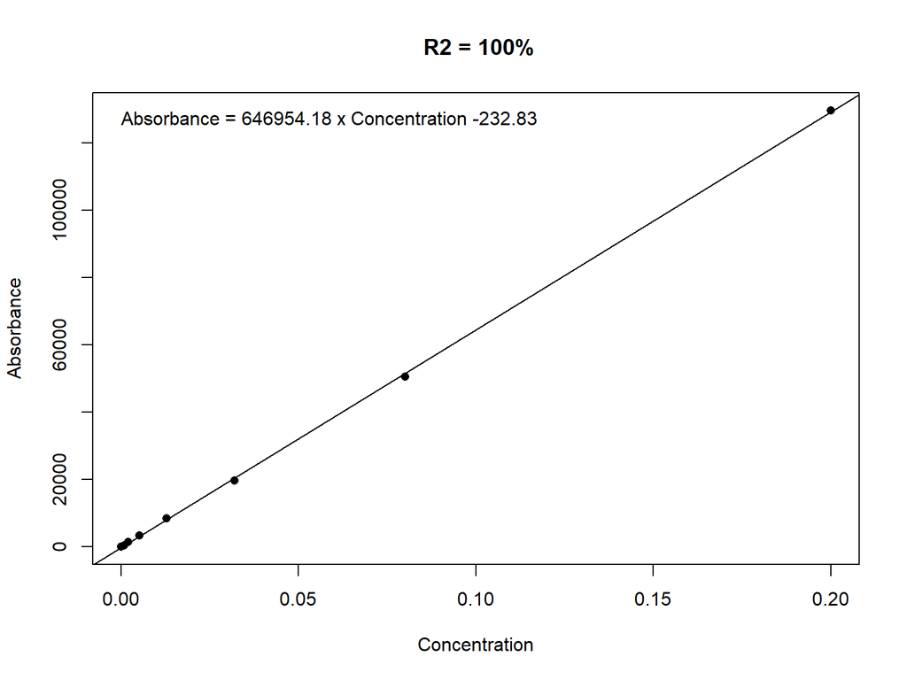

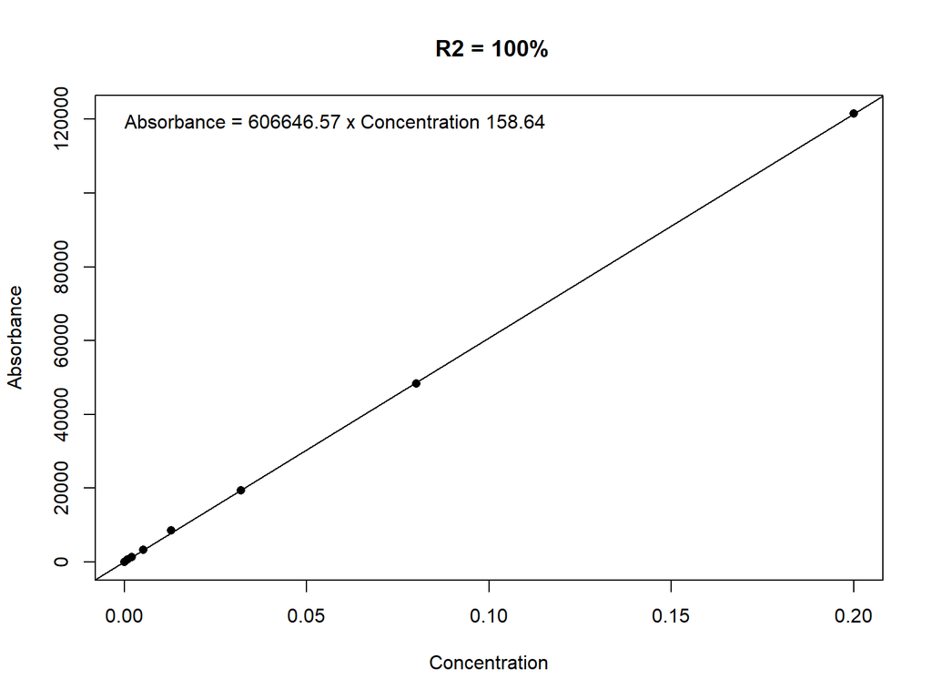

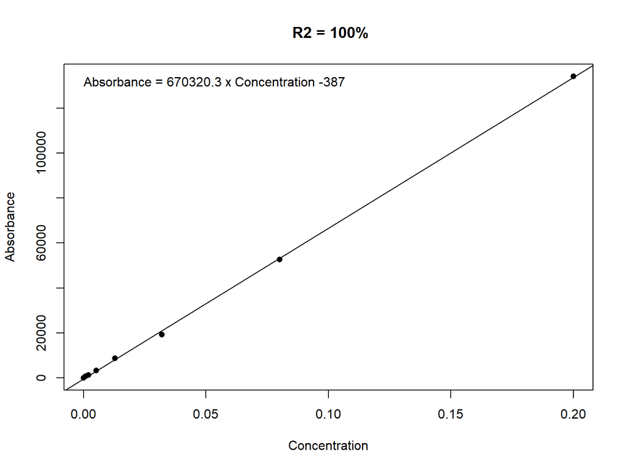

```r
standard_curve_fig <- function(plate, standard_names, standard_curve){
  # Plot of standards
  plot(corrected_abs ~ Cricket_ID, plate[plate$Cricket_ID %in% standard_names,],
       pch = 16,
       xlab = "Concentration",
       ylab = "Absorbance")
  # Fitted line
  abline(pluck(standard_curve, 4))
  # Plate ID and title
  title(paste0(" R2 = ", pluck(standard_curve, 1), "%"))
  # Equation of line
  text(y = max(plate$corrected_abs),
       x = 0,
       paste0("Absorbance = ", round(pluck(standard_curve, 2), 2), " x Concentration ", round(pluck(standard_curve, 3), 2)),
       adj = c(0, 1))
}
pmap(list(list_plate, list_standard_names, standard_curve), standard_curve_fig)
```

```r
f_samples <- function(plate, standard_curve, standard_names){
  plate %>%
    # Keep only samples
    filter(!Cricket_ID %in% c(standard_names)) %>%
    # Calculate well concentration
    mutate(sample_conc = (corrected_abs - pluck(standard_curve, 3)) / pluck(standard_curve, 2))
}

# Calculate well concentrations
sample_concs <- pmap(list(list_plate, standard_curve, list_standard_names), f_samples) %>% list_rbind()

# Add to the metadata file
samples <- left_join(metadata, sample_concs, by = "Cricket_ID")
```

# 4 Calculate haemolymph volume

Adjust for any dilutions relative to x10., 1 = x10, 2 = approx x20 or 5 uL in 90 uL. Less haem makes the sample more diluted so the concentration is lower and needs to be multiplied to adjust to the standards.

```r
stock_conc <- 4 # ug/uL
injected <- 1 # uL

# C1.V1 = C2.V2
samples$Haem_volume <- (stock_conc * injected) / (samples$sample_conc * samples$Dilution)
# Percentage of mass
samples$volume_pc <- (samples$Haem_volume / samples$End_mass) * 100
```

## 4.1 Final clean up

Cricket 153 likely has incorrect end mass - removed.  
Cricket 126 was dead in Drierite - Overly dry; removed.

18 hour crickets on plate 1 are removed and replaced (Exclusion)

```r
# Clean up
samples <- samples %>%
  mutate(Haem_volume = ifelse(Haem_volume >= 200, NA, Haem_volume)) %>%
  drop_na(Haem_volume) %>%
  # Remove first attempt crickets and crickets with no haemolymph
  filter(Exclusion == 0)
```

# 5 Summary stats

```r
mean_vol <- samples %>%
  group_by(Time, Sex) %>%
  summarise(n = n(),
            mean = mean(Haem_volume),
            se = sd(Haem_volume) / sqrt(n()),
            cv = (sd(Haem_volume) / mean) * 100)
knitr::kable(mean_vol, digits = 3)
```

| Time | Sex | n | mean | se | cv |
| --- | --- | --- | --- | --- | --- |
| 0 | Female | 18 | 144.551 | 5.723 | 16.797 |
| 0 | Male | 17 | 89.771 | 5.368 | 24.657 |
| 3 | Female | 16 | 126.964 | 7.543 | 23.766 |
| 3 | Male | 15 | 84.390 | 3.638 | 16.696 |
| 6 | Female | 16 | 139.853 | 5.743 | 16.425 |
| 6 | Male | 16 | 78.669 | 4.506 | 22.911 |
| 18 | Female | 17 | 95.349 | 5.440 | 23.522 |
| 18 | Male | 17 | 83.463 | 5.255 | 25.959 |
| 24 | Female | 16 | 121.460 | 5.804 | 19.114 |
| 24 | Male | 16 | 86.655 | 5.332 | 24.611 |

# 6 Haemolymph volume plot

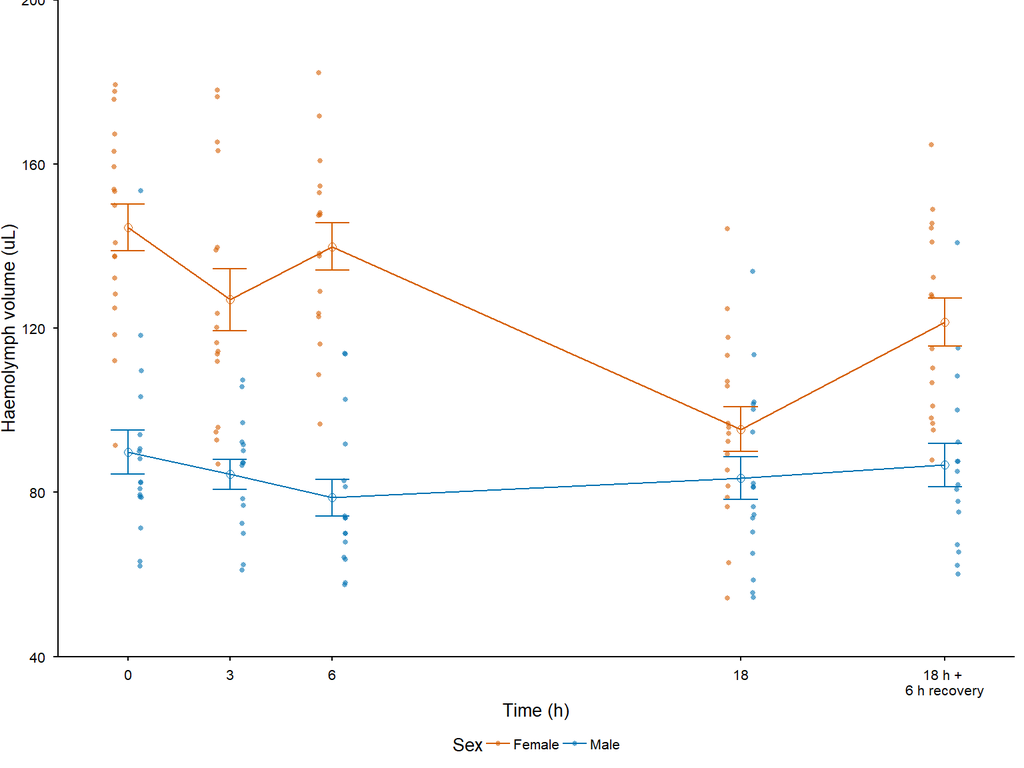

Haemolymph volume (uL) of female (orange) and male (blue) crickets after desiccation (hours). Error bars are standard error about the mean.

```r
p_volume <- ggplot() +
  geom_point(data = samples,
             aes(Time, Haem_volume, shape = Sex, colour = Sex),
             position = position_jitterdodge(jitter.width = 0.1, jitter.height = 0, dodge = 1.5), alpha = 0.6, stroke = NA) +
  geom_line(data = mean_vol, aes(Time, mean, group = Sex, colour = Sex), linewidth = 0.5) +
  geom_point(data = mean_vol, aes(Time, mean, colour = Sex),
             size = 2, shape = 1, show.legend = FALSE) +
  geom_errorbar(data = mean_vol, aes(Time, ymin = mean - se, ymax = mean + se,
                                     colour = Sex), width = 1, linewidth = 0.5) +
  scale_colour_manual(values = sex_pal) +
  scale_shape_manual(values = sex_point) +
  scale_y_continuous(name = "Haemolymph volume (uL)", limits = c(40, 200), expand = c(0,0)) +
  scale_x_continuous(name = "Time (h)", breaks = c(0, 3, 6, 18, 24), labels = c("0", "3", "6", "18", "18 h + \n6 h recovery"))

p_volume
```

```r
save(p_volume, file = "data/Desiccation 2025/figures/p_volume.rdata")

ggsave(p_volume &
  plot_annotation(tag_levels = list(c(""))), dpi = 300, width = single_width, units = "mm", height = single_height, filename = "data/Desiccation 2025/figures/Fig3haem_volume.png")
```

# 7 Stats

- Interaction between time and sex.
- Males have a smaller volume than females.
- Males do not change haemolymph volume.
- Females decrease haemolymph volume after 6 hours then recover some volume but not fully.
- Start mass does not differ among time treatments.

```r
samples$Time_fct <- as.factor(samples$Time)
hv_mod <- lm(Haem_volume ~ Start_mass + Time_fct * Sex, samples)

anova(hv_mod)
```

```
Analysis of Variance Table

Response: Haem_volume
              Df Sum Sq Mean Sq  F value                Pr(>F)
Start_mass     1  78904   78904 176.1180 < 0.00000000000000022 ***
Time_fct       4  12748    3187   7.1135            0.00002799 ***
Sex            1   1677    1677   3.7442               0.05484 .
Time_fct:Sex   4  11549    2887   6.4448            0.00008072 ***
Residuals    153  68547     448
---
Signif. codes:  0 '***' 0.001 '**' 0.01 '*' 0.05 '.' 0.1 ' ' 1
```

```r
pairs(emmeans(hv_mod, ~ Time_fct * Sex), adjust = "Tukey", by = "Sex")
```

```
Sex = Female:
 contrast                estimate   SE  df t.ratio p.value
 Time_fct0 - Time_fct3     13.974 7.32 153   1.910  0.3166
 Time_fct0 - Time_fct6      2.539 7.29 153   0.348  0.9968
 Time_fct0 - Time_fct18    46.574 7.18 153   6.484 <0.0001
 Time_fct0 - Time_fct24    18.277 7.35 153   2.486  0.0991
 Time_fct3 - Time_fct6    -11.435 7.49 153  -1.527  0.5468
 Time_fct3 - Time_fct18    32.600 7.38 153   4.420  0.0002
 Time_fct3 - Time_fct24     4.303 7.49 153   0.575  0.9786
 Time_fct6 - Time_fct18    44.035 7.37 153   5.972 <0.0001
 Time_fct6 - Time_fct24    15.738 7.51 153   2.097  0.2269
 Time_fct18 - Time_fct24  -28.297 7.39 153  -3.830  0.0017

Sex = Male:
 contrast                estimate   SE  df t.ratio p.value
 Time_fct0 - Time_fct3      5.820 7.50 153   0.776  0.9371
 Time_fct0 - Time_fct6     11.666 7.37 153   1.582  0.5111
 Time_fct0 - Time_fct18     6.579 7.26 153   0.906  0.8942
 Time_fct0 - Time_fct24     4.565 7.38 153   0.619  0.9719
 Time_fct3 - Time_fct6      5.846 7.61 153   0.768  0.9393
 Time_fct3 - Time_fct18     0.759 7.50 153   0.101  1.0000
 Time_fct3 - Time_fct24    -1.255 7.61 153  -0.165  0.9998
 Time_fct6 - Time_fct18    -5.087 7.37 153  -0.690  0.9584
 Time_fct6 - Time_fct24    -7.101 7.49 153  -0.949  0.8773
 Time_fct18 - Time_fct24   -2.014 7.38 153  -0.273  0.9988

P value adjustment: tukey method for comparing a family of 5 estimates
```

```r
emmeans(hv_mod, ~ Time_fct * Sex) %>%
  contrast(method = "trt.vs.ctrl", ref = 1, by = "Sex")
```

```
Sex = Female:
 contrast               estimate   SE  df t.ratio p.value
 Time_fct3 - Time_fct0    -13.97 7.32 153  -1.910  0.1823
 Time_fct6 - Time_fct0     -2.54 7.29 153  -0.348  0.9707
 Time_fct18 - Time_fct0   -46.57 7.18 153  -6.484 <0.0001
 Time_fct24 - Time_fct0   -18.28 7.35 153  -2.486  0.0492

Sex = Male:
 contrast               estimate   SE  df t.ratio p.value
 Time_fct3 - Time_fct0     -5.82 7.50 153  -0.776  0.8139
 Time_fct6 - Time_fct0    -11.67 7.37 153  -1.582  0.3284
 Time_fct18 - Time_fct0    -6.58 7.26 153  -0.906  0.7415
 Time_fct24 - Time_fct0    -4.56 7.38 153  -0.619  0.8879

P value adjustment: dunnettx method for 4 tests
```

# 8 Wet mass change

```r
# Percentage change (wet mass)
mean_pc_loss <- samples %>%
  filter(!Time %in% c("0")) %>%
  group_by(Sex, Desiccation_time) %>%
  distinct(Cricket_ID, Percent_change, Sex, Desiccation_time) %>%
  summarise(mean_pc_rate = mean(Percent_change, na.rm = TRUE),
            se_pc = sd(Percent_change, na.rm = TRUE) / sqrt(n()),
            range = max(Percent_change, na.rm = TRUE) - min(Percent_change, na.rm = TRUE),
            n = n())

knitr::kable(mean_pc_loss, digits = 3)
```

| Sex | Desiccation_time | mean_pc_rate | se_pc | range | n |
| --- | --- | --- | --- | --- | --- |
| Female | 3 | 2.095 | 0.242 | 3.479 | 16 |
| Female | 6 | 3.738 | 0.401 | 5.975 | 16 |
| Female | 18 | 9.828 | 0.456 | 12.389 | 33 |
| Male | 3 | 4.548 | 0.344 | 4.508 | 15 |
| Male | 6 | 6.899 | 0.517 | 6.008 | 16 |
| Male | 18 | 15.827 | 0.563 | 14.646 | 33 |

Interaction significant.

```r
PC_mod <- samples %>%
  filter(!Time %in% c("0")) %>%
  distinct(Cricket_ID, Percent_change, Sex, Desiccation_time) %>%
  lm(log(Percent_change) ~ log(Desiccation_time) * Sex, .)

PC_fit <- samples %>%
  filter(!Time %in% c("0")) %>%
  distinct(Cricket_ID, Percent_change, Sex, Desiccation_time) %>%
  select(Desiccation_time, Sex) %>%
  cbind(., exp(predict(PC_mod, newdata = ., interval = "prediction")))

summary(PC_mod)
```

```
Call:
lm(formula = log(Percent_change) ~ log(Desiccation_time) * Sex,
    data = .)

Residuals:
     Min       1Q   Median       3Q      Max
-0.84501 -0.19834 -0.03499  0.21387  0.82015

Coefficients:
                              Estimate Std. Error t value             Pr(>|t|)
(Intercept)                   -0.35313    0.11312  -3.122              0.00223
log(Desiccation_time)          0.90066    0.04900  18.380 < 0.0000000000000002
SexMale                        1.00159    0.16176   6.192        0.00000000786
log(Desiccation_time):SexMale -0.17993    0.06986  -2.576              0.01117

(Intercept)                   **
log(Desiccation_time)         ***
SexMale                       ***
log(Desiccation_time):SexMale *
---
Signif. codes:  0 '***' 0.001 '**' 0.01 '*' 0.05 '.' 0.1 ' ' 1

Residual standard error: 0.3012 on 125 degrees of freedom
Multiple R-squared:  0.8456,    Adjusted R-squared:  0.8419
F-statistic: 228.3 on 3 and 125 DF,  p-value: < 0.00000000000000022
```

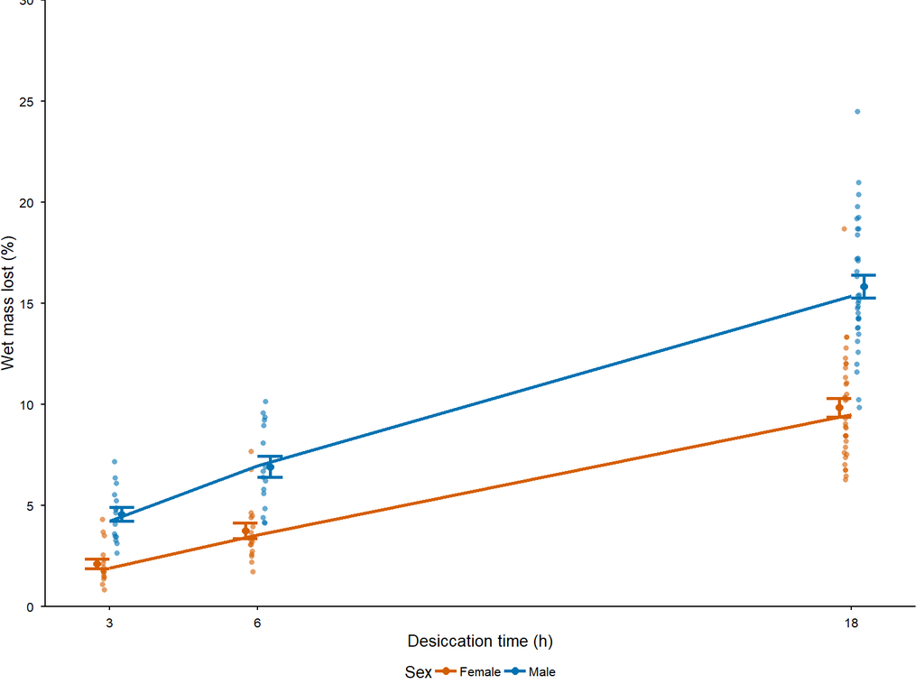

Change in wet mass (%) of crickets after desiccation. Females are orange. Males are blue. Lines are a fitted power function. Error bars are standard error around the mean.

```r
p_wetmass <- ggplot() +
  geom_point(data = samples %>%
               filter(!Time %in% c("0")), aes(Desiccation_time, Percent_change, colour = Sex), alpha = 0.6,
             position = position_jitterdodge(jitter.height = 0, jitter.width = 0.1, dodge = 0.5)) +
  geom_point(data = mean_pc_loss, aes(Desiccation_time, mean_pc_rate, colour = Sex),
              size = 2, shape = 16,
             position = position_dodge(1)) +
  geom_errorbar(data = mean_pc_loss, aes(Desiccation_time, colour = Sex,
                                            ymin = mean_pc_rate - se_pc,
                                            ymax = mean_pc_rate + se_pc),
                width = 1, linewidth = 1,
             position = position_dodge(1)) +
  geom_line(data = PC_fit, aes(Desiccation_time, fit, colour = Sex), linewidth = 1) +
  labs(y = "Wet mass lost (%)",
       x = "Desiccation time (h)") +
  scale_shape_manual(values = sex_point) +
  scale_colour_manual(values = sex_pal) +
  scale_y_continuous(limits = c(0, 30), breaks = seq(0, 35, 5), expand = expansion(mult = c(0.0, 0))) +
  scale_x_continuous(breaks = c(0, 3, 6, 18))

p_wetmass
```

# 9 Mass loss rate

```r
# Mass loss rate (wet mass)
mean_pc_rate <- samples %>%
  filter(!Time %in% c("0")) %>%
  group_by(Sex, Desiccation_time) %>%
  distinct(Cricket_ID, Mass_change_rate, Sex, Desiccation_time) %>%
  summarise(mean_pcr = mean(Mass_change_rate, na.rm = TRUE),
            se_pcr = sd(Mass_change_rate, na.rm = TRUE) / sqrt(n()),
            range = max(Mass_change_rate, na.rm = TRUE) - min(Mass_change_rate, na.rm = TRUE),
            n = n())

knitr::kable(mean_pc_rate, digits = 3)
```

| Sex | Desiccation_time | mean_pcr | se_pcr | range | n |
| --- | --- | --- | --- | --- | --- |
| Female | 3 | 0.698 | 0.081 | 1.160 | 16 |
| Female | 6 | 0.623 | 0.067 | 0.996 | 16 |
| Female | 18 | 0.546 | 0.025 | 0.688 | 33 |
| Male | 3 | 1.516 | 0.115 | 1.503 | 15 |
| Male | 6 | 1.150 | 0.086 | 1.001 | 16 |
| Male | 18 | 0.879 | 0.031 | 0.814 | 33 |

```r
pc_rate_mod <- samples %>%
  filter(!Time %in% c("0")) %>%
  distinct(Cricket_ID, log_pc_rate, Sex, Desiccation_time) %>%
  lm(log_pc_rate ~ Desiccation_time * Sex, .)

pc_rate_fit <- samples %>%
  filter(!Time %in% c("0")) %>%
  distinct(Cricket_ID, log_pc_rate, Sex, Desiccation_time) %>%
  select(Desiccation_time, Sex) %>%
  cbind(., 10^(predict(pc_rate_mod, newdata = ., interval="prediction")))

summary(pc_rate_mod)
```

```
Call:
lm(formula = log_pc_rate ~ Desiccation_time * Sex, data = .)

Residuals:
     Min       1Q   Median       3Q      Max
-0.35906 -0.08067 -0.01513  0.08824  0.36410

Coefficients:
                          Estimate Std. Error t value         Pr(>|t|)
(Intercept)              -0.194784   0.031819  -6.122 0.00000001104638 ***
Desiccation_time         -0.004631   0.002401  -1.928           0.0561 .
SexMale                   0.358694   0.045437   7.894 0.00000000000127 ***
Desiccation_time:SexMale -0.008308   0.003416  -2.432           0.0164 *
---
Signif. codes:  0 '***' 0.001 '**' 0.01 '*' 0.05 '.' 0.1 ' ' 1

Residual standard error: 0.1322 on 125 degrees of freedom
Multiple R-squared:  0.5603,    Adjusted R-squared:  0.5498
F-statistic:  53.1 on 3 and 125 DF,  p-value: < 0.00000000000000022
```

```r
pairs(emmeans(lm(log_pc_rate ~ as.factor(Desiccation_time) * Sex, filter(samples, Time != "0") %>% distinct(Cricket_ID, log_pc_rate, Sex, Desiccation_time)), ~ as.factor(Desiccation_time) * Sex), by = "Sex", adjust = "Tukey")
```

```
Sex = Female:
 contrast                               estimate     SE  df t.ratio p.value
 Desiccation_time3 - Desiccation_time6    0.0424 0.0465 123   0.912  0.6338
 Desiccation_time3 - Desiccation_time18   0.0806 0.0400 123   2.013  0.1134
 Desiccation_time6 - Desiccation_time18   0.0382 0.0400 123   0.954  0.6070

Sex = Male:
 contrast                               estimate     SE  df t.ratio p.value
 Desiccation_time3 - Desiccation_time6    0.1218 0.0472 123   2.578  0.0297
 Desiccation_time3 - Desiccation_time18   0.2279 0.0409 123   5.569 <0.0001
 Desiccation_time6 - Desiccation_time18   0.1062 0.0400 123   2.652  0.0244

P value adjustment: tukey method for comparing a family of 3 estimates
```

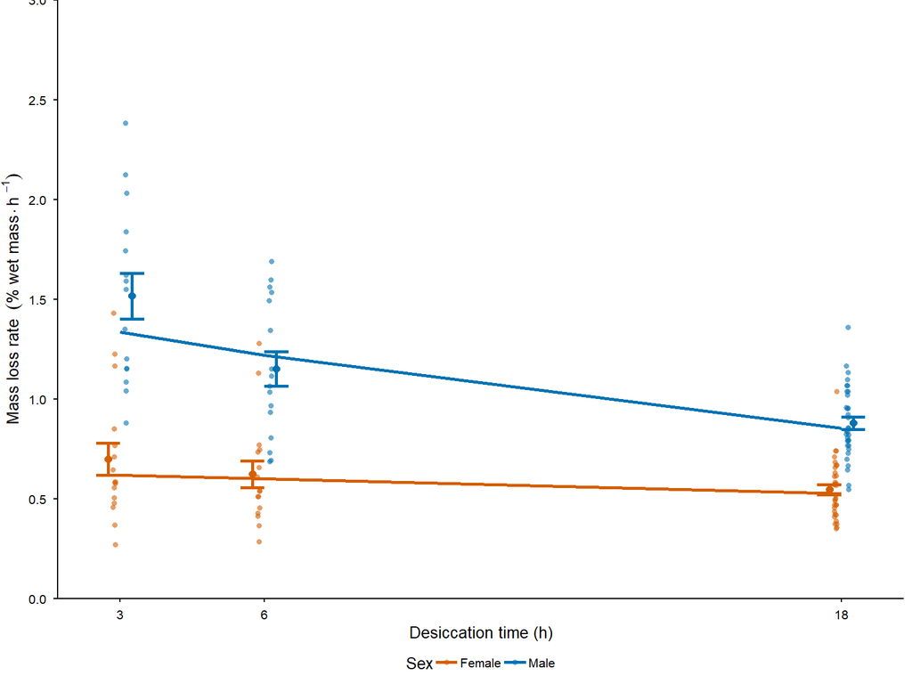

Mass loss rates of crickets (%/h). Females are orange. Males are blue. Lines are fitted power functions. Error bars are standard error around the mean.

```r
p_pc_rate <- ggplot() +
  geom_point(data = samples %>%
               filter(!Time %in% c("0")), aes(Desiccation_time, Mass_change_rate, colour = Sex), alpha = 0.6,
             position = position_jitterdodge(jitter.height = 0, jitter.width = 0.1, dodge = 0.5)) +
  geom_point(data = mean_pc_rate, aes(Desiccation_time, mean_pcr, colour = Sex),
              size = 2, shape = 16,
             position = position_dodge(1), show.legend = FALSE) +
  geom_errorbar(data = mean_pc_rate, aes(Desiccation_time, colour = Sex,
                                            ymin = mean_pcr - se_pcr,
                                            ymax = mean_pcr + se_pcr),
                width = 1, linewidth = 1,
             position = position_dodge(1)) +
  geom_line(data = pc_rate_fit, aes(Desiccation_time, fit, colour = Sex), linewidth = 1) +
  labs(y = expression("Mass loss rate " ~ ("% wet mass"%.%"h "^-1)),
       x = "Desiccation time (h)") +
  scale_shape_manual(values = sex_point) +
  scale_colour_manual(values = sex_pal) +
  scale_y_continuous(limits = c(0, 3), breaks = seq(0, 3.5, 0.5), expand = expansion(mult = c(0.0, 0))) +
  scale_x_continuous(breaks = c(0, 3, 6, 18))

p_pc_rate
```

# 10 Proportional water loss

```r
# Percentage change (water content)
mean_water_loss <- samples %>%
  filter(!Time %in% c("0")) %>%
  group_by(Sex, Desiccation_time) %>%
  distinct(Cricket_ID, Relative_water_loss, Sex, Desiccation_time) %>%
  summarise(mean_pc_rate = mean(Relative_water_loss, na.rm = TRUE),
            se_pc = sd(Relative_water_loss, na.rm = TRUE) / sqrt(n()),
            range = max(Relative_water_loss, na.rm = TRUE) - min(Relative_water_loss, na.rm = TRUE),
            n = n())

knitr::kable(mean_water_loss, digits = 3)
```

| Sex | Desiccation_time | mean_pc_rate | se_pc | range | n |
| --- | --- | --- | --- | --- | --- |
| Female | 3 | 3.266 | 0.381 | 5.698 | 16 |
| Female | 6 | 5.746 | 0.588 | 8.724 | 16 |
| Female | 18 | 14.801 | 0.624 | 16.357 | 33 |
| Male | 3 | 6.105 | 0.436 | 5.808 | 15 |
| Male | 6 | 9.318 | 0.660 | 7.663 | 16 |
| Male | 18 | 20.752 | 0.704 | 18.734 | 33 |

# 11 Water loss rate

```r
# Water loss rate (relative water content)
mean_WLR <- samples %>%
  filter(!Time %in% c("0")) %>%
  drop_na(Dry_mass_mg) %>%
  group_by(Sex, Desiccation_time) %>%
  distinct(Cricket_ID, WLR, Sex, Desiccation_time) %>%
  summarise(mean_WLR = mean(WLR, na.rm = TRUE),
            se_WLR = sd(WLR, na.rm = TRUE) / sqrt(n()),
            range = max(WLR, na.rm = TRUE) - min(WLR, na.rm = TRUE),
            n = n())

knitr::kable(mean_WLR, digits = 3)
```

| Sex | Desiccation_time | mean_WLR | se_WLR | range | n |
| --- | --- | --- | --- | --- | --- |
| Female | 3 | 1.089 | 0.127 | 1.899 | 16 |
| Female | 6 | 0.958 | 0.098 | 1.454 | 16 |
| Female | 18 | 0.822 | 0.035 | 0.909 | 33 |
| Male | 3 | 2.035 | 0.145 | 1.936 | 15 |
| Male | 6 | 1.553 | 0.110 | 1.277 | 16 |
| Male | 18 | 1.153 | 0.039 | 1.041 | 33 |

```r
WLR_mod <- samples %>%
  filter(!Time %in% c("0")) %>%
  distinct(Cricket_ID, log_WLR, Sex, Desiccation_time) %>%
  lm(log_WLR ~ Desiccation_time * Sex, .)
# Interaction dropped

WLR_fit <- samples %>%
  filter(!Time %in% c("0")) %>%
  distinct(Cricket_ID, log_WLR, Sex, Desiccation_time) %>%
  select(Desiccation_time, Sex) %>%
  cbind(., 10^(predict(WLR_mod, newdata = ., interval="prediction")))

summary(WLR_mod)
```

```
Call:
lm(formula = log_WLR ~ Desiccation_time * Sex, data = .)

Residuals:
     Min       1Q   Median       3Q      Max
-0.36172 -0.07550 -0.00279  0.08060  0.38156

Coefficients:
                           Estimate Std. Error t value      Pr(>|t|)
(Intercept)              -0.0001344  0.0305327  -0.004        0.9965
Desiccation_time         -0.0054466  0.0023043  -2.364        0.0196 *
SexMale                   0.2991943  0.0435998   6.862 0.00000000028 ***
Desiccation_time:SexMale -0.0084039  0.0032782  -2.564        0.0115 *
---
Signif. codes:  0 '***' 0.001 '**' 0.01 '*' 0.05 '.' 0.1 ' ' 1

Residual standard error: 0.1269 on 125 degrees of freedom
Multiple R-squared:  0.4951,    Adjusted R-squared:  0.4829
F-statistic: 40.85 on 3 and 125 DF,  p-value: < 0.00000000000000022
```

```r
pairs(emmeans(lm(log_WLR ~ as.factor(Desiccation_time) * Sex, filter(samples, Time != "0") %>% distinct(Cricket_ID, log_WLR, Sex, Desiccation_time)), ~ as.factor(Desiccation_time) * Sex), adjust = "Tukey", by = "Sex")
```

```
Sex = Female:
 contrast                               estimate     SE  df t.ratio p.value
 Desiccation_time3 - Desiccation_time6    0.0459 0.0446 123   1.029  0.5600
 Desiccation_time3 - Desiccation_time18   0.0932 0.0384 123   2.426  0.0438
 Desiccation_time6 - Desiccation_time18   0.0473 0.0384 123   1.232  0.4369

Sex = Male:
 contrast                               estimate     SE  df t.ratio p.value
 Desiccation_time3 - Desiccation_time6    0.1190 0.0453 123   2.624  0.0263
 Desiccation_time3 - Desiccation_time18   0.2394 0.0393 123   6.092 <0.0001
 Desiccation_time6 - Desiccation_time18   0.1204 0.0384 123   3.131  0.0061

P value adjustment: tukey method for comparing a family of 3 estimates
```

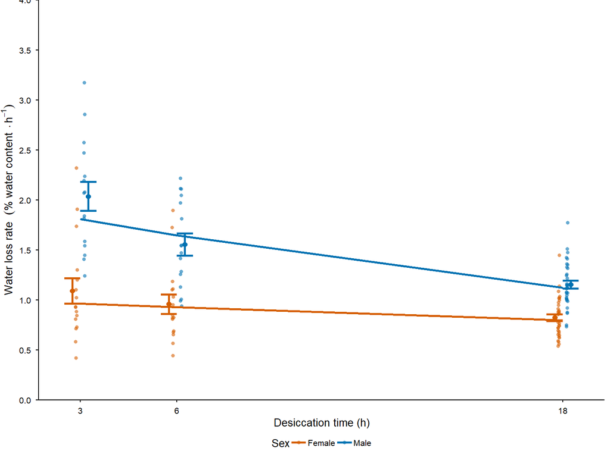

Water loss rates of crickets relative to total water content (%/h). Females are orange. Males are blue. Lines are fitted power functions. Error bars are standard error around the mean.

```r
p_WLR <- ggplot() +
  geom_point(data = samples %>%
               filter(!Time %in% c("0")), aes(Desiccation_time, WLR, colour = Sex), alpha = 0.6,
             position = position_jitterdodge(jitter.height = 0, jitter.width = 0.1, dodge = 0.5)) +
  geom_point(data = mean_WLR, aes(Desiccation_time, mean_WLR, colour = Sex),
              size = 2, shape = 16,
             position = position_dodge(1), show.legend = FALSE) +
  geom_errorbar(data = mean_WLR, aes(Desiccation_time, colour = Sex,
                                            ymin = mean_WLR - se_WLR,
                                            ymax = mean_WLR + se_WLR),
                width = 1, linewidth = 1,
             position = position_dodge(1)) +
  geom_line(data = WLR_fit, aes(Desiccation_time, fit, colour = Sex), linewidth = 1) +
  labs(y = expression("Water loss rate " ~ ("% water content "%.%"h"^-1)),
       x = "Desiccation time (h)") +
  scale_shape_manual(values = sex_point) +
  scale_colour_manual(values = sex_pal) +
  scale_y_continuous(limits = c(0, 4), breaks = seq(0, 5, 0.5), expand = expansion(mult = c(0.0, 0))) +
  scale_x_continuous(breaks = c(0, 3, 6, 18))

p_WLR
```

# 12 Rehydration

Crickets recover on average 92% of their initial mass. Some individuals do not recover mass.

```r
rehydration_volume <- metadata %>%
  filter(Time == 24) %>%
  select(Cricket_ID, Sex, Percent_change, Percent_change_recovery) %>%
  mutate(Start_Percent = 100,
         Percent_change = 100 - Percent_change) %>%
  pivot_longer(contains("Percent"), names_to = "Timepoint", values_to = "Change") %>%
  mutate(Experiment = "Volume",
         Time_treatment = "24_starved",
         Timepoint = factor(Timepoint, levels = c("Start_Percent", "Percent_change", "Percent_change_recovery")))

save(samples, rehydration_volume, file = "data/Desiccation 2025/volume.Rdata")
```

# 13 Correlations

Is there a correlation between volume and wet mass lost?

```r
volmass_mod <- lm(Haem_volume ~ Percent_change * Sex, filter(samples, Time != 0))
summary(volmass_mod)
```

```
Call:
lm(formula = Haem_volume ~ Percent_change * Sex, data = filter(samples,
    Time != 0))

Residuals:
    Min      1Q  Median      3Q     Max
-64.923 -15.625  -2.657  14.627  55.710

Coefficients:
                       Estimate Std. Error t value             Pr(>|t|)
(Intercept)            136.3542     5.5303  24.656 < 0.0000000000000002 ***
Percent_change          -2.4655     0.7278  -3.388             0.000943 ***
SexMale                -57.3859     8.4868  -6.762       0.000000000466 ***
Percent_change:SexMale   2.8592     0.8952   3.194             0.001777 **
---
Signif. codes:  0 '***' 0.001 '**' 0.01 '*' 0.05 '.' 0.1 ' ' 1

Residual standard error: 23.8 on 125 degrees of freedom
Multiple R-squared:  0.4211,    Adjusted R-squared:  0.4072
F-statistic: 30.31 on 3 and 125 DF,  p-value: 0.000000000000008532
```

```r
slopes <- emtrends(volmass_mod, "Sex", var = "Percent_change")
summary(slopes, infer = c(TRUE, TRUE), null = 0)
```

```
 Sex    Percent_change.trend    SE  df lower.CL upper.CL t.ratio p.value
 Female               -2.465 0.728 125   -3.906    -1.03  -3.388  0.0009
 Male                  0.394 0.521 125   -0.638     1.43   0.755  0.4515

Confidence level used: 0.95
```

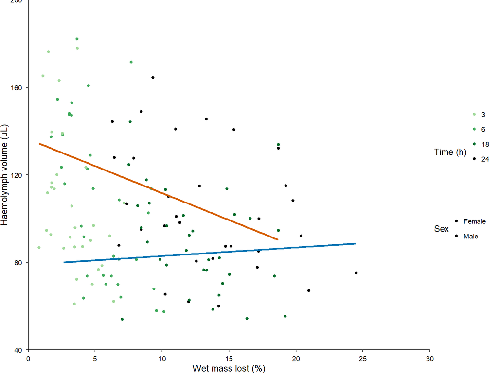

```r
ggplot(filter(samples, Time != 0), aes(Percent_change, Haem_volume, colour = Time_fct, shape = Sex)) +
  geom_point() +
  geom_smooth(method = "lm", se = FALSE, aes(group = Sex, color = Sex), show.legend = FALSE) +
  scale_colour_manual(values = c("#a1d99b", "#41ab5d", "#006d2c", "black", sex_pal), labels = c("3", "6", "18", "24", "", ""), name = "Time (h)") +
  scale_y_continuous(name = "Haemolymph volume (uL)", limits = c(40, 200), expand = c(0,0)) +
    scale_x_continuous(name = "Wet mass lost (%)", limits = c(0, 30), breaks = seq(0, 35, 5), expand = expansion(mult = c(0.0, 0))) +
  theme(legend.position = "right") +
  scale_shape_manual(values = sex_point)
```

Is there a correlation between volume and % water lost? Yes

Crickets are losing water during desiccation and it is correlated with haemolymph volume but only in females.

```r
summary(lm(Haem_volume ~ Relative_water_loss + Sex, filter(samples, !Time %in% c(0, 24))))
```

```
Call:
lm(formula = Haem_volume ~ Relative_water_loss + Sex, data = filter(samples,
    !Time %in% c(0, 24)))

Residuals:
    Min      1Q  Median      3Q     Max
-62.221 -15.776  -3.106  13.997  66.225

Coefficients:
                    Estimate Std. Error t value             Pr(>|t|)
(Intercept)         129.5778     4.9164  26.356 < 0.0000000000000002 ***
Relative_water_loss  -1.1645     0.4234  -2.751              0.00714 **
SexMale             -33.4048     5.3129  -6.288         0.0000000101 ***
---
Signif. codes:  0 '***' 0.001 '**' 0.01 '*' 0.05 '.' 0.1 ' ' 1

Residual standard error: 24.81 on 94 degrees of freedom
Multiple R-squared:  0.4074,    Adjusted R-squared:  0.3948
F-statistic: 32.31 on 2 and 94 DF,  p-value: 0.00000000002092
```

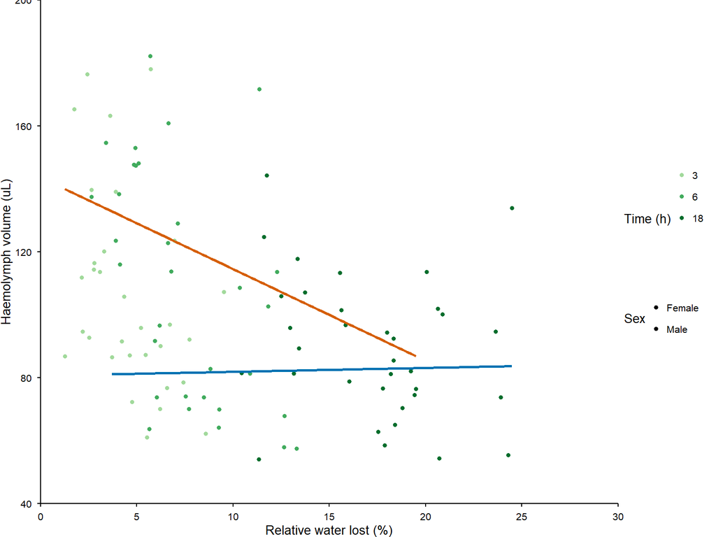

```r
ggplot(filter(samples,!Time %in% c(0, 24)), aes(Relative_water_loss, Haem_volume, colour = Time_fct, shape = Sex)) +
  geom_point() +
  geom_smooth(method = "lm", se = FALSE, aes(group = Sex, color = Sex), show.legend = FALSE) +
  scale_colour_manual(values = c("#a1d99b", "#41ab5d", "#006d2c", sex_pal), labels = c("3", "6", "18", "", ""), name = "Time (h)") +
  scale_y_continuous(name = "Haemolymph volume (uL)", limits = c(40, 200), expand = c(0,0)) +
    scale_x_continuous(name = "Relative water lost (%)", limits = c(0, 30), breaks = seq(0, 35, 5), expand = expansion(mult = c(0.0, 0))) +
  theme(legend.position = "right") +
  scale_shape_manual(values = sex_point)
```

Is there a correlation between proportion of mass recovered and of haemolymph volume? No

```r
filter(samples, Time == 24) %>%
  mutate(rehydration = ifelse(Sex == "Female", (Haem_volume / 144.551) * 100,
                                 (Haem_volume / 89.771) * 100)) %>%
  cor.test(~rehydration + Percent_change_recovery, data = .)
```

```
    Pearson's product-moment correlation

data:  rehydration and Percent_change_recovery
t = -0.70163, df = 30, p-value = 0.4883
alternative hypothesis: true correlation is not equal to 0
95 percent confidence interval:
 -0.4555716  0.2319067
sample estimates:
      cor
-0.127062
```

Does dry mass change? Indicating that tissue mass is used during desiccation Generally, no. But females at 24 h have lower dry mass than control crickets. But no other pairwise differences are different.

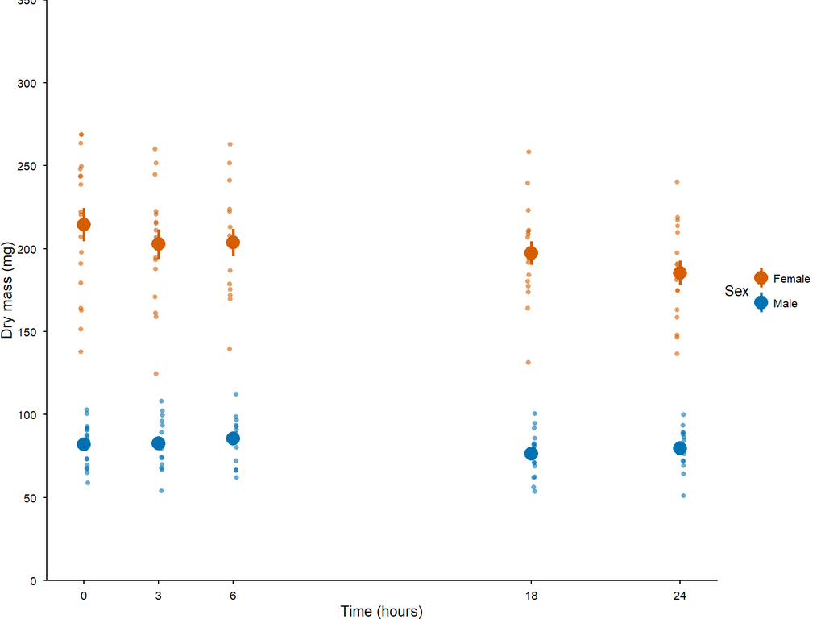

```r
ggplot(samples, aes(Time, Dry_mass_mg, colour = Sex, shape = Sex)) +
  geom_point(alpha = 0.6,
             position = position_jitterdodge(jitter.height = 0, jitter.width = 0.1, dodge = 0.5)) + scale_colour_manual(values = sex_pal) +
  scale_shape_manual(values = sex_point) +
  scale_y_continuous(name = "Dry mass (mg)", limits = c(0, 350), expand = c(0,0), breaks = seq(0, 400, 50)) +
  scale_x_continuous(name = "Time (hours)", breaks = c(0, 3, 6, 18, 24), labels = c("0", "3", "6", "18", "24")) +
  theme(legend.position = "right") +
  stat_summary(fun.data = "mean_se", size = 1, linewidth = 1)
```

```r
pairs(emmeans(lm(Dry_mass_mg ~ Time_fct * Sex,  samples), ~ Time_fct * Sex), adjust = "Tukey", by = "Sex") %>%
  broom::tidy() %>%
  filter(adj.p.value <= 0.05)
```

```
# A tibble: 1 × 9
  Sex    term     contrast               null.value estimate std.error    df
  <chr>  <chr>    <chr>                       <dbl>    <dbl>     <dbl> <dbl>
1 Female Time_fct Time_fct0 - Time_fct24          0 29.26743  9.052538   154
  statistic adj.p.value
      <dbl>       <dbl>
1  3.233064  0.01284012
```